# Diversity analysis

# county analysis

Regress difference in diversity (four-group entropy) on percent population change using piecewise regression. Enter separate variables for percent population loss just for pop. loss counties, i.e., variable is coded 0 where percent pop loss >= 0 and given the actual percent population loss when less than 0. I multiplied this variable by -1 so that positive coefficients for this variable would be interpreted as the effect for a one-percent increase in population *loss*. All county-level models include state-level fixed effects. Sample includes only counties in the contiguous US, excluding DC. See Glaeser’s [“Durable Housing” paper](https://scholar.harvard.edu/glaeser/publications/urban-decline-and-durable-housing) for similar use of piecewise pop loss and pop gain variables.

In addition to using OLS to predict differences in diversity, I estiamte a logit model predicting the binary outcome of whether or not a county experienced a negative change in diversity. This seems to be the phenomenon of primary interest. Positive coefficients for pop. change in an OLS model predicting differences in diversity are useful for indicating whether more growth is linked to increased diversity, but not whether pop decline is linked to negative or positive changes in diversity. Indeed, only counties with extreme levels of population loss were predicted to have negative differences in diversity. The majority of counties, including pop. loss counties, experienced some degree of increase in diversity.

## ols model

```r
# load data
df_cty <- read.csv(file = "/home/eric/Documents/franklin/narsc2018/generated_data/county_regression_data.csv",
               header = TRUE, sep = ",")
df_cty$STATE <- factor(df_cty$STATE)
df_cty$region <- factor(df_cty$region)
```

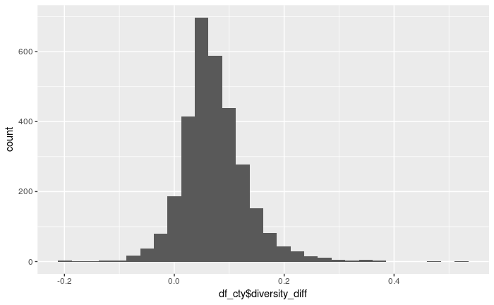

```r
# plot histogram from difference in diversity
qplot(df_cty$diversity_diff, geom = "histogram")
```

Note that most values for the DV are positive.

```r
# xtab frequences of loss counties and loss in diversity
# intl is coded 1 for pop. loss counties
# diversity_decline is coded 1 for diversity loss counties
df_cty %>%
  count(intl, diversity_decline) %>%
  mutate(prop = prop.table(n))
```

| intl | diversity_decline | n | prop |
| --- | --- | --- | --- |
| 0 | 0 | 1917 | 0.61739130 |
| 0 | 1 | 103 | 0.03317230 |
| 1 | 0 | 974 | 0.31368760 |
| 1 | 1 | 111 | 0.03574879 |

```r
# percentage of loss counties that lost diversity
111 / (111+974) * 100
```

```
[1] 10.23041
```

```r
# Run model: OLS diff in diversity 2000 to 2010
# include pop loss and pop gain piecewise
cty_ols_pwise <- lm(diversity_diff ~ pop_loss + pop_gain + pwhite_00 + log(pop00) + STATE , data = df_cty)
```

```r
# Adjust standard errors for heterskedasticity
# coeftest(cty_ols_pwise, vcov = vcovHC(cty_ols_pwise, "HC1"))
cov1 <- vcovHC(cty_ols_pwise, type = "HC1")
robust_se1 <- sqrt(diag(cov1))
# report default and robust standard errors
stargazer(cty_ols_pwise, cty_ols_pwise, se=list(NULL, robust_se1),
          omit = "STATE", notes = c("State fixed effects omitted"),
          column.labels = c("default", "robust"), align = TRUE, single.row = TRUE,
          type="text")
```

```
===================================================================
                                        Dependent variable:
                                -----------------------------------
                                          diversity_diff
                                     default           robust
                                       (1)               (2)
-------------------------------------------------------------------
pop_loss                        -0.001** (0.0003)  -0.001 (0.0004)
pop_gain                        0.001*** (0.0001) 0.001*** (0.0002)
pwhite_00                       0.105*** (0.007)  0.105*** (0.009)
log(pop00)                      0.013*** (0.001)  0.013*** (0.001)
Constant                        -0.145*** (0.013) -0.145*** (0.018)
-------------------------------------------------------------------
Observations                          3,105             3,105
R2                                    0.325             0.325
Adjusted R2                           0.313             0.313
Residual Std. Error (df = 3053)       0.050             0.050
F Statistic (df = 51; 3053)         28.761***         28.761***
===================================================================
Note:                                   *p<0.1; **p<0.05; ***p<0.01
                                        State fixed effects omitted
```

Robust standard errors indicate pop loss in these models is not associated with county differences in diversity scores, while pop. gain is positively associated with change in diversity. Inital pop and percent white are also associated with increased diversity.

## county logit model

Predict loss of diversity as binary outcome. Code counties as 1 where difference < 0 and 0 otherwise.

```r
cty_logit_pwise <- glm(formula = diversity_decline ~ pop_loss + pop_gain + pwhite_00 + log(pop00) + STATE,
              data = df_cty, family = "binomial")
# summary(cty_logit_pwise)
cov1 <- vcovHC(cty_logit_pwise, type = "HC1")
robust_se1 <- sqrt(diag(cov1))
#
# report default and robust standard errors
stargazer(cty_logit_pwise, cty_logit_pwise, se=list(NULL, robust_se1),
          omit = "STATE", notes = c("State fixed effects omitted", "Coeffs are untransformed logits"),
          column.labels = c("default", "robust"), align = TRUE, single.row = TRUE,
          type="text")
```

```
the condition has length > 1 and only the first element will be usedthe condition has length > 1 and only the first element will be used
```

```
=====================================================
                          Dependent variable:
                  -----------------------------------
                           diversity_decline
                       default           robust
                         (1)               (2)
-----------------------------------------------------
pop_loss          0.071*** (0.018)  0.071*** (0.022)
pop_gain            0.007 (0.010)     0.007 (0.009)
pwhite_00         -6.484*** (0.512) -6.484*** (0.570)
log(pop00)        -0.395*** (0.076) -0.395*** (0.083)
Constant          4.805*** (1.032)  4.805*** (1.143)
-----------------------------------------------------
Observations            3,105             3,105
Log Likelihood        -532.504          -532.504
Akaike Inf. Crit.     1,169.008         1,169.008
=====================================================
Note:                     *p<0.1; **p<0.05; ***p<0.01
                          State fixed effects omitted
                      Coeffs are untransformed logits
```

Pop. loss is associated with greater odds of a decrease in diversity, while pop gain is not associated with the binary outcome of loss vs. gain.

```r
# express as odds ratios
OR.vector <- exp(cty_logit_pwise$coef)
p.values <- summary(cty_logit_pwise)$coefficients[,4]

stargazer(cty_logit_pwise, coef = list(OR.vector), p = list(p.values),
          align = TRUE, single.row = TRUE,
          omit = "STATE", notes = c("STATE fixed effects omitted", "Coeffs are odds ratios"),
          type="text")
```

```
the condition has length > 1 and only the first element will be used
```

```
=============================================
                      Dependent variable:
                  ---------------------------
                       diversity_decline
---------------------------------------------
pop_loss               1.074*** (0.018)
pop_gain                 1.007 (0.010)
pwhite_00              0.002*** (0.512)
log(pop00)             0.674*** (0.076)
Constant              122.087*** (1.032)
---------------------------------------------
Observations                 3,105
Log Likelihood             -532.504
Akaike Inf. Crit.          1,169.008
=============================================
Note:             *p<0.1; **p<0.05; ***p<0.01
                  STATE fixed effects omitted
                       Coeffs are odds ratios
```

# tract analysis

Sample includes all tracts in 50 largest MSAs. Dropped tracts w/ fewer than 100 people in 2000 to reduce extreme change observations. Models include MSA fixed effects and dummy for outlying vs. central county.

```r
# load data
df_trt <- read.csv(file = "/home/eric/Documents/franklin/narsc2018/generated_data/tract_regression_data.csv",
               header = TRUE, sep = ",")
df_trt$CBSA_Title <- factor(df_trt$CBSA_Title)
df_trt$Central_Outlying_County <- factor(df_trt$Central_Outlying_County)
```

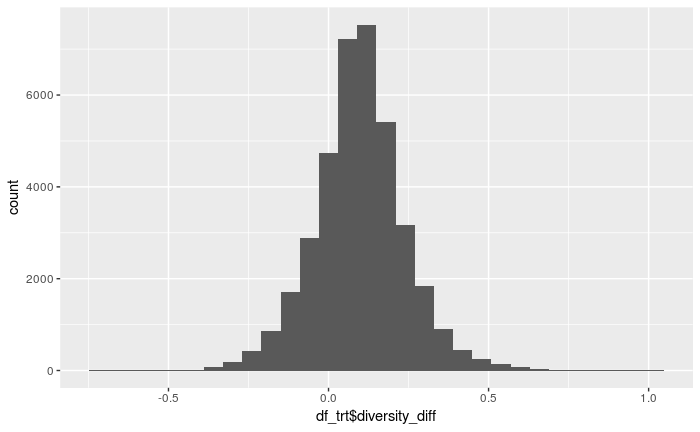

```r
# plot DV - difference in diversity
qplot(df_trt$diversity_diff, geom = "histogram")
```

```r
# how many loss tracts?
# loss counted as 1, so 16387 loss counties
df_trt %>%
  count(intl, diversity_decline) %>%
  mutate(prop = prop.table(n))
```

| intl | diversity_decline | n | prop |
| --- | --- | --- | --- |
| 0 | 0 | 17446 | 0.4583935 |
| 0 | 1 | 4226 | 0.1110381 |
| 1 | 0 | 12283 | 0.3227358 |
| 1 | 1 | 4104 | 0.1078326 |

```r
# percentage of loss tracts that lost diversity
4101 / (4104+12283) * 100
```

```
[1] 25.02594
```

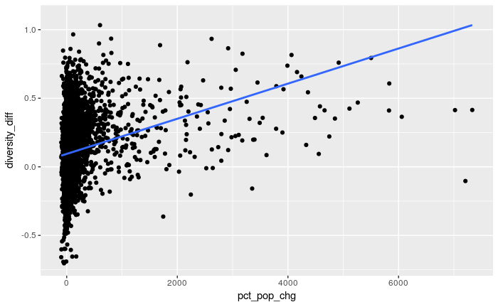

```r
# plot change in diversity against change in pop. for all tracts
df_trt %>%
  ggplot(aes(y = diversity_diff, x = pct_pop_chg)) +
  geom_point() +
  geom_smooth(method = "lm", fill = NA)
```

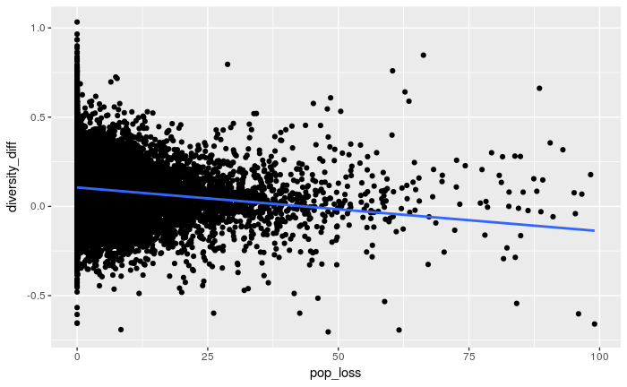

```r
# plot change in diversity against change in pop. for shrinking tracts
df_trt %>%
  ggplot(aes(y = diversity_diff, x = pop_loss)) +
  geom_point() +
  geom_smooth(method = "lm", fill = NA)
```

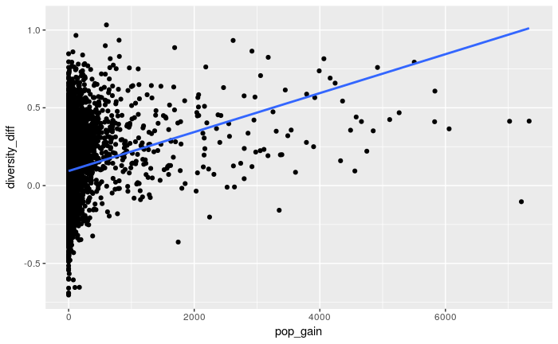

```r
# plot change in diversity against change in pop. for growing tracts
df_trt %>%
  ggplot(aes(y = diversity_diff, x = pop_gain)) +
  geom_point() +
  geom_smooth(method = "lm", fill = NA)
```

## ols model

Predict difference in diversity on pop. loss and pop. gain. Includes MSA fixed effects.

```r
# Run model: OLS diff in diversity 2000 to 2010
# include pop loss and pop gain piecewise
trt_ols_pwise <- lm(formula = diversity_diff ~ pop_loss + pop_gain + pwhite_00 + log(pop00)
         + CBSA_Title + Central_Outlying_County, data = df_trt)
# Adjust standard errors
# coeftest(cty_ols_pwise, vcov = vcovHC(cty_ols_pwise, "HC1"))
cov1 <- vcovHC(trt_ols_pwise, type = "HC1")
robust_se1 <- sqrt(diag(cov1))
# report default and robust standard errors
stargazer(trt_ols_pwise, trt_ols_pwise, se=list(NULL, robust_se1),
          omit = "CBSA", notes = c("MSA fixed effects omitted"),
          column.labels = c("default", "robust"), align = TRUE, single.row = TRUE,
          type="text")
```

```
========================================================================
                                           Dependent variable:
                                 ---------------------------------------
                                             diversity_diff
                                       default             robust
                                         (1)                 (2)
------------------------------------------------------------------------
pop_loss                          -0.0001 (0.0001)    -0.0001 (0.0002)
pop_gain                         0.0001*** (0.00000) 0.0001*** (0.00001)
pwhite_00                         0.211*** (0.002)    0.211*** (0.003)
log(pop00)                        -0.020*** (0.001)   -0.020*** (0.002)
Central_Outlying_CountyOutlying   -0.044*** (0.003)   -0.044*** (0.002)
Constant                          0.204*** (0.012)    0.204*** (0.017)
------------------------------------------------------------------------
Observations                           38,059              38,059
R2                                      0.296               0.296
Adjusted R2                             0.295               0.295
Residual Std. Error (df = 38004)        0.121               0.121
F Statistic (df = 54; 38004)         295.457***          295.457***
========================================================================
Note:                                        *p<0.1; **p<0.05; ***p<0.01
                                               MSA fixed effects omitted
```

Pop loss not associated with change in diversity in this model, while pop. gain associated with increase. Percent white in 2000 is highly positively associated with increases in diversity. Initial population negatively associated with increasing diversity. Tracts in outlying counties associated with smaller increases in diversity relative to tracts in central counties.

## logit model

Predict binary outcome of decrease in diversity.

```r
trt_logit_pwise <- glm(formula = diversity_decline ~ pop_loss + pop_gain + pwhite_00 + log(pop00)
                       + CBSA_Title + Central_Outlying_County,
                       data = df_trt, family = "binomial")
# summary(trt_logit_pwise)
cov1 <- vcovHC(trt_logit_pwise, type = "HC1")
robust_se1 <- sqrt(diag(cov1))
#
# report default and robust standard errors
stargazer(trt_logit_pwise, trt_logit_pwise, se=list(NULL, robust_se1),
          omit = "CBSA", notes = c("CBSA fixed effects omitted", "Coeffs are untransformed logits"),
          column.labels = c("default", "robust"), align = TRUE, single.row = TRUE,
          type="text")
```

```
the condition has length > 1 and only the first element will be usedthe condition has length > 1 and only the first element will be used
```

```
====================================================================
                                        Dependent variable:
                                ------------------------------------
                                         diversity_decline
                                     default            robust
                                       (1)                (2)
--------------------------------------------------------------------
pop_loss                        -0.015*** (0.002)  -0.015*** (0.003)
pop_gain                        -0.0003** (0.0001) -0.0003* (0.0002)
pwhite_00                       -4.275*** (0.056)  -4.275*** (0.059)
log(pop00)                       0.162*** (0.034)  0.162*** (0.040)
Central_Outlying_CountyOutlying   0.010 (0.080)      0.010 (0.080)
Constant                         -0.560* (0.306)    -0.560 (0.353)
--------------------------------------------------------------------
Observations                          38,059            38,059
Log Likelihood                     -14,105.380        -14,105.380
Akaike Inf. Crit.                   28,320.750        28,320.750
====================================================================
Note:                                    *p<0.1; **p<0.05; ***p<0.01
                                          CBSA fixed effects omitted
                                     Coeffs are untransformed logits
```

Pop loss and pop gain are both associated with *lower* odds of diversity loss. Coefficient is larger for loss tracts. Initial percent white has a substantial association w/ decreased odds of declining diversity.

```r
# express as odds ratios
OR.vector <- exp(trt_logit_pwise$coef)
p.values <- summary(trt_logit_pwise)$coefficients[,4]

stargazer(trt_logit_pwise, coef = list(OR.vector), p = list(p.values),
          align = TRUE, single.row = TRUE,
          omit = "CBSA", notes = c("CBSA fixed effects omitted", "Coeffs are odds ratios"),
          type="text")
```

```
the condition has length > 1 and only the first element will be used
```

```
===========================================================
                                    Dependent variable:
                                ---------------------------
                                     diversity_decline
-----------------------------------------------------------
pop_loss                             0.985*** (0.002)
pop_gain                             1.000** (0.0001)
pwhite_00                            0.014*** (0.056)
log(pop00)                           1.175*** (0.034)
Central_Outlying_CountyOutlying        1.010 (0.080)
Constant                              0.571* (0.306)
-----------------------------------------------------------
Observations                              38,059
Log Likelihood                          -14,105.380
Akaike Inf. Crit.                       28,320.750
===========================================================
Note:                           *p<0.1; **p<0.05; ***p<0.01
                                 CBSA fixed effects omitted
                                     Coeffs are odds ratios
```